# Applying logit model for predicting a stroke risk

Edyta Pszczółkowska

10 06 2021

```r
knitr::opts_chunk$set(warning = FALSE, message = FALSE)
```

## Abstract

The main aim of this project was to check which health and social-economic status data are significant in terms of predicting whether a given person is prone to suffering from stroke. The analysis was performed on a dataset taken from Kaggle portal. The used method was to build logit model and to choose significant variables by applying general-to-specific (GETS) approach. After choosing statistically significant variables, quality tests were performed. The conclusions that could be drawn from this analysis were that some information that should be obviously included in the model are not significant (like whether a person suffers from heart disease or not). Such an analysis can be used in advanced research on cardiovascular illnesses or its prevention.

## Introduction

Cardiovascular disease (CVD) is a general term for conditions affecting the heart or blood vessels. It’s usually associated with a build-up of fatty deposits inside the arteries (atherosclerosis) and an increased risk of blood clots. It is one of the most frequent cause of deaths in the whole European Union and other developed countries. One of the most frequent cases is stroke - which means that the blood supply to part of the brain is cut off, which can cause brain damage and possibly death. The goal of my work was to check which characteristics may rise the risk of suffering from stroke in the future.

MY HYPOTHESIS which I wanted to prove is that the only significant traits that can be used in predicting stroke are those related directly to health and lifestyle. In case of my dataset these are: gender, age, whether person suffers from hypertension and heart diseases or not, glucose level and bmi index level. On the other hand those which I want to prove as insignificant are marital status, residence type or work type. My intuition about it is supported by research on that matter and general knowledge about healthy life style. The risk factors of stroke are nicely summed up here: http://www.fum.info.pl/page/index/35 .

## Data and its preparation

The dataset was taken from Kaggle portal (https://www.kaggle.com/fedesoriano/stroke-prediction-dataset) and consists of 12 following variables, all of them rather self-explanatory:

```r
setwd("D:\\Edyta pliki\\DS\\II semestr\\AE")
data <- read.csv("healthcare-dataset-stroke-data.csv")
library(lmtest)
colnames(data)
```

```
##  [1] "id"                "gender"            "age"
##  [4] "hypertension"      "heart_disease"     "ever_married"
##  [7] "work_type"         "Residence_type"    "avg_glucose_level"
## [10] "bmi"               "smoking_status"    "stroke"
```

I will remove the “id” variable:

```r
data$id <- NULL
```

The variable of special interest is “stroke” variable - dichotomous variable indicating whether a person suffered from a stroke or not. This will be the dependent variable in my model.

```r
data$stroke <- as.factor(data$stroke)
```

Let’s inspect all other variables one-by-one:

```r
table(data$gender)
```

```
##
## Female   Male  Other
##   2994   2115      1
```

As there is only one person with “other” as gender, I will delete this record to make variable binary:

```r
data <- data[data$gender != "Other", ]
data$gender <- as.factor(data$gender)
```

Variable age:

```r
summary(data$age)
```

```
##    Min. 1st Qu.  Median    Mean 3rd Qu.    Max.
##    0.08   25.00   45.00   43.23   61.00   82.00
```

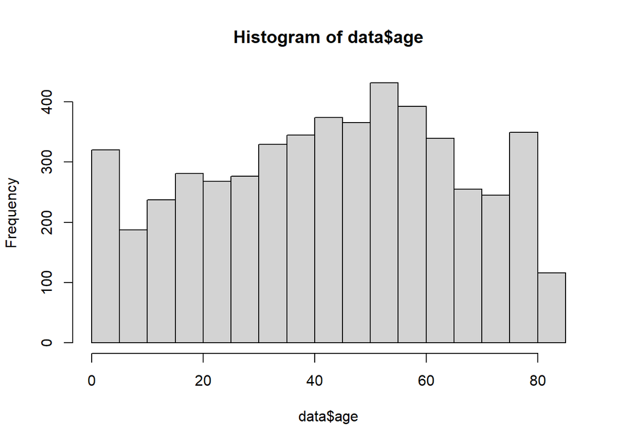

```r
hist(data$age)
```

```r
table(data$age[data$stroke == 1])
```

```
##
## 1.32   14   32   38   39   42   43   45   46   47   48   49   50   51   52   53
##    1    1    1    2    3    1    1    3    1    1    2    3    3    4    2    2
##   54   55   56   57   58   59   60   61   63   64   65   66   67   68   69   70
##    6    2    3   11    7    8    4    6    9    3    3    4    3    9    6    6
##   71   72   73   74   75   76   77   78   79   80   81   82
##    7    6    4    9    6   10    8   21   17   17   14    9
```

This variable is very widely distributed. As we can see, in the dataset there were only two children who suffered from a stroke. To make the model more plausible, I will delete those records, where age is less than 20. Also medical articles support my choice: https://www.ncbi.nlm.nih.gov/pmc/articles/PMC3475622/

```r
data <- data[data$age > 20 ,]
```

I will convert the descritpion of “hypertension” and “heart_disease” variables from 0/1 notation to the more explanatory one and make sure that all remaining dichotomous variables are treated as factors.

```r
data$hypertension <- ifelse(data$hypertension == 1, "yes", "no")


data$heart_disease <- ifelse(data$heart_disease == 1, "yes", "no")

data$hypertension <- as.factor(data$hypertension)

data$heart_disease <- as.factor(data$heart_disease)

data$ever_married <- as.factor(data$ever_married)


data$Residence_type <- as.factor(data$Residence_type)
```

Average glucose level is measured in [mg/dl] units. The distribution of data:

```r
summary(data$avg_glucose_level)
```

```
##    Min. 1st Qu.  Median    Mean 3rd Qu.    Max.
##   55.12   77.46   92.59  109.10  116.80  271.74
```

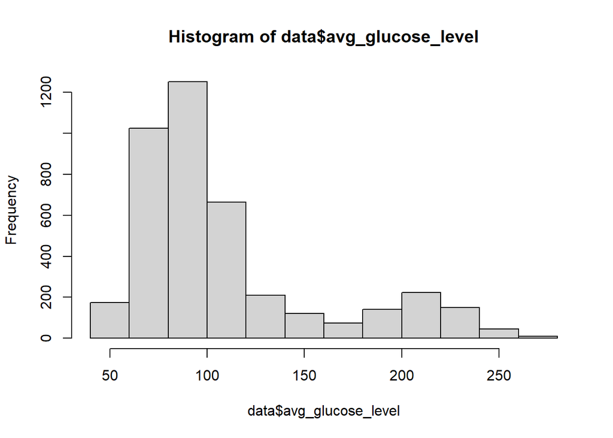

```r
hist(data$avg_glucose_level)
```

To make analysis easier I will divide the variable into intervals according to their interpretation (source: https://diabetyk24.pl/blog-section/Badania-cukru-we-krwi)

```r
data$glucose <- ifelse(data$avg_glucose_level < 70, "hypoglycemia", ifelse(data$avg_glucose_level >= 70 & data$avg_glucose_level < 100 , "normal", ifelse(data$avg_glucose_level >= 100 & data$avg_glucose_level < 126, "pre-diabetes", "diabetes")  ))

data$avg_glucose_level <- NULL
table(data$glucose)
```

```
##
##     diabetes hypoglycemia       normal pre-diabetes
##          878          593         1858          755
```

```r
data$glucose <- as.factor(data$glucose)
```

BMI index is counted as follows: BMI_index = weight[kg]/ height^2[m^2] The distribution of data:

```r
data$bmi <- as.numeric(data$bmi)

summary(data$bmi)
```

```
##    Min. 1st Qu.  Median    Mean 3rd Qu.    Max.    NA's
##   11.30   25.60   29.40   30.61   34.30   92.00     176
```

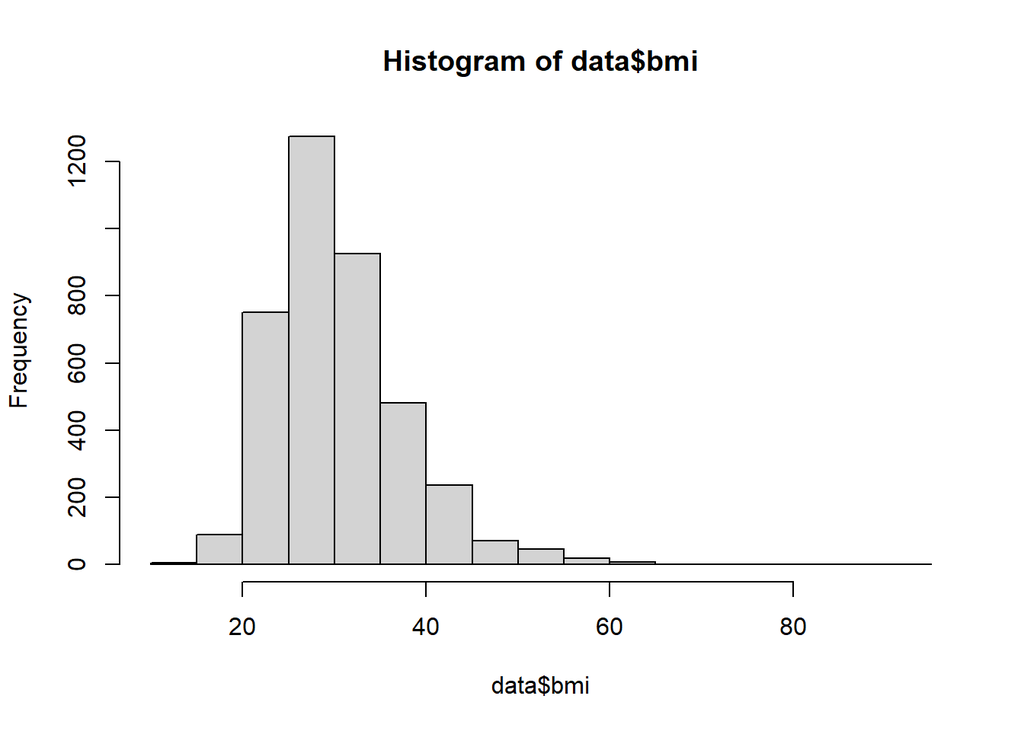

```r
hist(data$bmi)
```

To make analysis easier I will divide variable into intervals according to their interpretation (source: https://www.cdc.gov/healthyweight/assessing/bmi/adult_bmi/index.html) To get rid of the problem of missing values, I will convert them into “unknown” category.

```r
data$bmi2 <- ifelse(data$bmi < 18.5, "underweight", ifelse(data$bmi >= 18.5 & data$bmi < 25 , "healthy weight", ifelse(data$bmi >= 25 & data$bmi < 30, "overweight", "obese")  ))


table(data$bmi2)
```

```
##
## healthy weight          obese     overweight    underweight
##            785           1818           1272             33
```

```r
data$bmi2[is.na(data$bmi2)] <- 'unknown'
data$bmi2 <- as.factor(data$bmi2)
data$bmi <- NULL
```

A mysterious variable “work_type”:

```r
table(data$work_type)
```

```
##
##      Govt_job  Never_worked       Private Self-employed
##           643             1          2638           802
```

```r
data$work_type <- as.factor(data$work_type)
```

From my personal point of view, the categories are not informative enough to give any valuable information. Nevertheless I will take this variable into account in my further analysis.

Last but not least - smoking status:

```r
table(data$smoking_status)
```

```
##
## formerly smoked    never smoked          smokes         Unknown
##             853            1672             760             799
```

```r
data$smoking_status <- as.factor(data$smoking_status)
```

Let’s take a look at the variables altogether:

```r
summary(data)
```

```
##     gender          age       hypertension heart_disease ever_married
##  Female:2476   Min.   :21.0   no :3588     no :3809      No : 738
##  Male  :1608   1st Qu.:38.0   yes: 496     yes: 275      Yes:3346
##                Median :51.0
##                Mean   :51.5
##                3rd Qu.:65.0
##                Max.   :82.0
##          work_type    Residence_type         smoking_status stroke
##  Govt_job     : 643   Rural:1997     formerly smoked: 853   0:3837
##  Never_worked :   1   Urban:2087     never smoked   :1672   1: 247
##  Private      :2638                  smokes         : 760
##  Self-employed: 802                  Unknown        : 799
##
##
##          glucose                 bmi2
##  diabetes    : 878   healthy weight: 785
##  hypoglycemia: 593   obese         :1818
##  normal      :1858   overweight    :1272
##  pre-diabetes: 755   underweight   :  33
##                      unknown       : 176
##
```

## Building logit model and applying GETS approach

Firstly I will try to build a logit model. Once after applying GETS approach, I will choose only significant variables and then compare with appropriate measures logit and probit model.

```r
model1 <- glm(stroke ~ gender + age + hypertension  + heart_disease + ever_married  + work_type +  Residence_type +
                glucose  + smoking_status + bmi2, data = data, family=binomial(link="logit"))
summary(model1)
```

```
##
## Call:
## glm(formula = stroke ~ gender + age + hypertension + heart_disease +
##     ever_married + work_type + Residence_type + glucose + smoking_status +
##     bmi2, family = binomial(link = "logit"), data = data)
##
## Deviance Residuals:
##     Min       1Q   Median       3Q      Max
## -1.5486  -0.3580  -0.2115  -0.1228   3.1512
##
## Coefficients:
##                              Estimate Std. Error z value Pr(>|z|)
## (Intercept)                 -6.853688   0.531553 -12.894  < 2e-16 ***
## genderMale                   0.006191   0.144834   0.043  0.96591
## age                          0.073842   0.005925  12.463  < 2e-16 ***
## hypertensionyes              0.339738   0.166894   2.036  0.04179 *
## heart_diseaseyes             0.193961   0.193770   1.001  0.31683
## ever_marriedYes             -0.224633   0.226476  -0.992  0.32126
## work_typeNever_worked       -6.899487 324.744011  -0.021  0.98305
## work_typePrivate             0.157547   0.208388   0.756  0.44963
## work_typeSelf-employed      -0.221829   0.235414  -0.942  0.34604
## Residence_typeUrban          0.057575   0.140542   0.410  0.68205
## glucosehypoglycemia         -0.580806   0.241823  -2.402  0.01632 *
## glucosenormal               -0.514722   0.167608  -3.071  0.00213 **
## glucosepre-diabetes         -0.400356   0.213551  -1.875  0.06083 .
## smoking_statusnever smoked  -0.174659   0.177215  -0.986  0.32434
## smoking_statussmokes         0.058171   0.218045   0.267  0.78963
## smoking_statusUnknown       -0.182828   0.212749  -0.859  0.39014
## bmi2obese                    0.029429   0.215847   0.136  0.89155
## bmi2overweight               0.056277   0.222404   0.253  0.80024
## bmi2underweight             -0.857956   1.050129  -0.817  0.41393
## bmi2unknown                  1.308659   0.274451   4.768 1.86e-06 ***
## ---
## Signif. codes:  0 '***' 0.001 '**' 0.01 '*' 0.05 '.' 0.1 ' ' 1
##
## (Dispersion parameter for binomial family taken to be 1)
##
##     Null deviance: 1864.6  on 4083  degrees of freedom
## Residual deviance: 1518.7  on 4064  degrees of freedom
## AIC: 1558.7
##
## Number of Fisher Scoring iterations: 11
```

By applying GETS approach, in the next iterations we delete the least significant variables, in other words, the one with the highest p-value of coefficients. In our case “gender” :

```r
model2 <- glm(stroke ~  age + hypertension  + heart_disease + ever_married  + work_type +  Residence_type +
                glucose  + smoking_status + bmi2, data = data, family=binomial(link="logit"))

lrtest(model1, model2)
```

```
## Likelihood ratio test
##
## Model 1: stroke ~ gender + age + hypertension + heart_disease + ever_married +
##     work_type + Residence_type + glucose + smoking_status + bmi2
## Model 2: stroke ~ age + hypertension + heart_disease + ever_married +
##     work_type + Residence_type + glucose + smoking_status + bmi2
##   #Df  LogLik Df  Chisq Pr(>Chisq)
## 1  20 -759.34
## 2  19 -759.34 -1 0.0018     0.9659
```

The lrtest compares full (model1) and nested models (model2). The null hypothesis of such a test is that all the rejected variables are jointly insignificant. P-value greater than 5%, we fail to reject null hypothesis , that variable “gender” is insignificant.

```r
summary(model2)
```

```
##
## Call:
## glm(formula = stroke ~ age + hypertension + heart_disease + ever_married +
##     work_type + Residence_type + glucose + smoking_status + bmi2,
##     family = binomial(link = "logit"), data = data)
##
## Deviance Residuals:
##     Min       1Q   Median       3Q      Max
## -1.5501  -0.3579  -0.2115  -0.1229   3.1501
##
## Coefficients:
##                              Estimate Std. Error z value Pr(>|z|)
## (Intercept)                 -6.851055   0.527939 -12.977  < 2e-16 ***
## age                          0.073834   0.005922  12.469  < 2e-16 ***
## hypertensionyes              0.339669   0.166891   2.035   0.0418 *
## heart_diseaseyes             0.194811   0.192757   1.011   0.3122
## ever_marriedYes             -0.224127   0.226172  -0.991   0.3217
## work_typeNever_worked       -6.894246 324.743988  -0.021   0.9831
## work_typePrivate             0.157741   0.208343   0.757   0.4490
## work_typeSelf-employed      -0.221824   0.235414  -0.942   0.3461
## Residence_typeUrban          0.057479   0.140524   0.409   0.6825
## glucosehypoglycemia         -0.581287   0.241569  -2.406   0.0161 *
## glucosenormal               -0.515044   0.167443  -3.076   0.0021 **
## glucosepre-diabetes         -0.400720   0.213383  -1.878   0.0604 .
## smoking_statusnever smoked  -0.175700   0.175530  -1.001   0.3168
## smoking_statussmokes         0.057849   0.217914   0.265   0.7907
## smoking_statusUnknown       -0.183308   0.212449  -0.863   0.3882
## bmi2obese                    0.030044   0.215360   0.140   0.8891
## bmi2overweight               0.057289   0.221134   0.259   0.7956
## bmi2underweight             -0.858682   1.049993  -0.818   0.4135
## bmi2unknown                  1.309611   0.273550   4.787 1.69e-06 ***
## ---
## Signif. codes:  0 '***' 0.001 '**' 0.01 '*' 0.05 '.' 0.1 ' ' 1
##
## (Dispersion parameter for binomial family taken to be 1)
##
##     Null deviance: 1864.6  on 4083  degrees of freedom
## Residual deviance: 1518.7  on 4065  degrees of freedom
## AIC: 1556.7
##
## Number of Fisher Scoring iterations: 11
```

Let’s get rid of “work_type” variable as all p-values of the coefficients next to its levels are all very high (just like my intuition told me):

```r
model3 <- glm(stroke ~  age + hypertension  + heart_disease + ever_married  +  Residence_type +
                glucose  + smoking_status + bmi2, data = data, family=binomial(link="logit"))

lrtest(model1, model3)
```

```
## Likelihood ratio test
##
## Model 1: stroke ~ gender + age + hypertension + heart_disease + ever_married +
##     work_type + Residence_type + glucose + smoking_status + bmi2
## Model 2: stroke ~ age + hypertension + heart_disease + ever_married +
##     Residence_type + glucose + smoking_status + bmi2
##   #Df  LogLik Df  Chisq Pr(>Chisq)
## 1  20 -759.34
## 2  16 -762.00 -4 5.3131     0.2567
```

p-value greater than 5%, so we fail to reject null hypothesis , that variables “gender” and “work type” are jointly insignificant

```r
summary(model3)
```

```
##
## Call:
## glm(formula = stroke ~ age + hypertension + heart_disease + ever_married +
##     Residence_type + glucose + smoking_status + bmi2, family = binomial(link = "logit"),
##     data = data)
##
## Deviance Residuals:
##     Min       1Q   Median       3Q      Max
## -1.4688  -0.3586  -0.2143  -0.1235   3.1564
##
## Coefficients:
##                             Estimate Std. Error z value Pr(>|z|)
## (Intercept)                -6.642231   0.498585 -13.322  < 2e-16 ***
## age                         0.070832   0.005732  12.357  < 2e-16 ***
## hypertensionyes             0.329219   0.166444   1.978  0.04793 *
## heart_diseaseyes            0.207832   0.192090   1.082  0.27927
## ever_marriedYes            -0.207799   0.225727  -0.921  0.35727
## Residence_typeUrban         0.061484   0.140221   0.438  0.66104
## glucosehypoglycemia        -0.603504   0.241330  -2.501  0.01239 *
## glucosenormal              -0.524930   0.166908  -3.145  0.00166 **
## glucosepre-diabetes        -0.424942   0.212790  -1.997  0.04583 *
## smoking_statusnever smoked -0.173367   0.175297  -0.989  0.32267
## smoking_statussmokes        0.064424   0.217607   0.296  0.76719
## smoking_statusUnknown      -0.171949   0.211883  -0.812  0.41706
## bmi2obese                   0.039460   0.215016   0.184  0.85439
## bmi2overweight              0.069210   0.220776   0.313  0.75391
## bmi2underweight            -0.819198   1.048195  -0.782  0.43449
## bmi2unknown                 1.314071   0.272537   4.822 1.42e-06 ***
## ---
## Signif. codes:  0 '***' 0.001 '**' 0.01 '*' 0.05 '.' 0.1 ' ' 1
##
## (Dispersion parameter for binomial family taken to be 1)
##
##     Null deviance: 1864.6  on 4083  degrees of freedom
## Residual deviance: 1524.0  on 4068  degrees of freedom
## AIC: 1556
##
## Number of Fisher Scoring iterations: 7
```

Let’s remove smoking status as all p-values of the coefficients next to its levels are all very high:

```r
model4 <- glm(stroke ~  age + hypertension  + heart_disease + ever_married  +  Residence_type +
                glucose  +  bmi2, data = data, family=binomial(link="logit"))

lrtest(model1, model4)
```

```
## Likelihood ratio test
##
## Model 1: stroke ~ gender + age + hypertension + heart_disease + ever_married +
##     work_type + Residence_type + glucose + smoking_status + bmi2
## Model 2: stroke ~ age + hypertension + heart_disease + ever_married +
##     Residence_type + glucose + bmi2
##   #Df  LogLik Df  Chisq Pr(>Chisq)
## 1  20 -759.34
## 2  13 -763.01 -7 7.3409     0.3943
```

p-value greater than 5%, so we fail to reject null hypothesis , that variables “gender” “smoking status” and “work type” are jointly insignificant

```r
summary(model4)
```

```
##
## Call:
## glm(formula = stroke ~ age + hypertension + heart_disease + ever_married +
##     Residence_type + glucose + bmi2, family = binomial(link = "logit"),
##     data = data)
##
## Deviance Residuals:
##     Min       1Q   Median       3Q      Max
## -1.4295  -0.3579  -0.2159  -0.1256   3.1998
##
## Coefficients:
##                      Estimate Std. Error z value Pr(>|z|)
## (Intercept)         -6.704397   0.473918 -14.147  < 2e-16 ***
## age                  0.070143   0.005633  12.453  < 2e-16 ***
## hypertensionyes      0.330223   0.165236   1.999  0.04566 *
## heart_diseaseyes     0.227603   0.191396   1.189  0.23437
## ever_marriedYes     -0.195967   0.225641  -0.868  0.38513
## Residence_typeUrban  0.071532   0.139986   0.511  0.60936
## glucosehypoglycemia -0.605765   0.241328  -2.510  0.01207 *
## glucosenormal       -0.527906   0.166704  -3.167  0.00154 **
## glucosepre-diabetes -0.421233   0.212464  -1.983  0.04741 *
## bmi2obese            0.040142   0.214758   0.187  0.85173
## bmi2overweight       0.070388   0.220621   0.319  0.74969
## bmi2underweight     -0.817682   1.047631  -0.781  0.43509
## bmi2unknown          1.322403   0.271243   4.875 1.09e-06 ***
## ---
## Signif. codes:  0 '***' 0.001 '**' 0.01 '*' 0.05 '.' 0.1 ' ' 1
##
## (Dispersion parameter for binomial family taken to be 1)
##
##     Null deviance: 1864.6  on 4083  degrees of freedom
## Residual deviance: 1526.0  on 4071  degrees of freedom
## AIC: 1552
##
## Number of Fisher Scoring iterations: 7
```

Let’s remove “Residence_type” variable

```r
model5 <- glm(stroke ~  age + hypertension  + heart_disease + ever_married  +
                glucose  +  bmi2, data = data, family=binomial(link="logit"))

lrtest(model1, model5)
```

```
## Likelihood ratio test
##
## Model 1: stroke ~ gender + age + hypertension + heart_disease + ever_married +
##     work_type + Residence_type + glucose + smoking_status + bmi2
## Model 2: stroke ~ age + hypertension + heart_disease + ever_married +
##     glucose + bmi2
##   #Df  LogLik Df  Chisq Pr(>Chisq)
## 1  20 -759.34
## 2  12 -763.14 -8 7.6023     0.4733
```

p-value greater than 5%, we fail to reject null hypothesis, that variables “Residence_type”, “smoking status”, “work type” and “gender” are jointly insignificant

```r
summary(model5)
```

```
##
## Call:
## glm(formula = stroke ~ age + hypertension + heart_disease + ever_married +
##     glucose + bmi2, family = binomial(link = "logit"), data = data)
##
## Deviance Residuals:
##     Min       1Q   Median       3Q      Max
## -1.4160  -0.3607  -0.2139  -0.1254   3.1896
##
## Coefficients:
##                     Estimate Std. Error z value Pr(>|z|)
## (Intercept)         -6.66819    0.46834 -14.238  < 2e-16 ***
## age                  0.07028    0.00563  12.482  < 2e-16 ***
## hypertensionyes      0.32638    0.16507   1.977  0.04802 *
## heart_diseaseyes     0.22500    0.19131   1.176  0.23956
## ever_marriedYes     -0.20032    0.22548  -0.888  0.37432
## glucosehypoglycemia -0.60867    0.24129  -2.523  0.01165 *
## glucosenormal       -0.52950    0.16665  -3.177  0.00149 **
## glucosepre-diabetes -0.42261    0.21240  -1.990  0.04663 *
## bmi2obese            0.03859    0.21474   0.180  0.85738
## bmi2overweight       0.06841    0.22057   0.310  0.75645
## bmi2underweight     -0.82611    1.04777  -0.788  0.43044
## bmi2unknown          1.32461    0.27117   4.885 1.03e-06 ***
## ---
## Signif. codes:  0 '***' 0.001 '**' 0.01 '*' 0.05 '.' 0.1 ' ' 1
##
## (Dispersion parameter for binomial family taken to be 1)
##
##     Null deviance: 1864.6  on 4083  degrees of freedom
## Residual deviance: 1526.3  on 4072  degrees of freedom
## AIC: 1550.3
##
## Number of Fisher Scoring iterations: 7
```

Let’s relevel “bmi2” variable: the insignificant levels (“underweight”, “overweight” ," obese“) and the base level (”healthy weight“) will be described as one base level and the only significant level (”unknown") will remain without changes:

```r
levels(data$bmi2)[levels(data$bmi2)=="obese"] = "base level"
levels(data$bmi2)[levels(data$bmi2)=="healthy weight"] = "base level"
levels(data$bmi2)[levels(data$bmi2)=="overweight"] = "base level"
levels(data$bmi2)[levels(data$bmi2)=="underweight"] = "base level"
```

Let’s create now again the same model, but with releveled “bmi2” variable

```r
model5 <- glm(stroke ~  age + hypertension  + heart_disease + ever_married  +
                glucose  +  bmi2, data = data, family=binomial(link="logit"))

summary(model5)
```

```
##
## Call:
## glm(formula = stroke ~ age + hypertension + heart_disease + ever_married +
##     glucose + bmi2, family = binomial(link = "logit"), data = data)
##
## Deviance Residuals:
##     Min       1Q   Median       3Q      Max
## -1.4154  -0.3599  -0.2134  -0.1256   3.1985
##
## Coefficients:
##                     Estimate Std. Error z value Pr(>|z|)
## (Intercept)         -6.61859    0.42424 -15.601  < 2e-16 ***
## age                  0.07007    0.00558  12.557  < 2e-16 ***
## hypertensionyes      0.32838    0.16452   1.996  0.04594 *
## heart_diseaseyes     0.23382    0.19120   1.223  0.22136
## ever_marriedYes     -0.19845    0.22506  -0.882  0.37789
## glucosehypoglycemia -0.61389    0.23981  -2.560  0.01047 *
## glucosenormal       -0.53431    0.16487  -3.241  0.00119 **
## glucosepre-diabetes -0.42628    0.21140  -2.016  0.04375 *
## bmi2unknown          1.28727    0.21238   6.061 1.35e-09 ***
## ---
## Signif. codes:  0 '***' 0.001 '**' 0.01 '*' 0.05 '.' 0.1 ' ' 1
##
## (Dispersion parameter for binomial family taken to be 1)
##
##     Null deviance: 1864.6  on 4083  degrees of freedom
## Residual deviance: 1527.3  on 4075  degrees of freedom
## AIC: 1545.3
##
## Number of Fisher Scoring iterations: 7
```

Let’s remove “ever married” variable:

```r
model6 <- glm(stroke ~  age + hypertension  + heart_disease +
                glucose  +  bmi2, data = data, family=binomial(link="logit"))

lrtest(model1, model6)
```

```
## Likelihood ratio test
##
## Model 1: stroke ~ gender + age + hypertension + heart_disease + ever_married +
##     work_type + Residence_type + glucose + smoking_status + bmi2
## Model 2: stroke ~ age + hypertension + heart_disease + glucose + bmi2
##   #Df  LogLik  Df  Chisq Pr(>Chisq)
## 1  20 -759.34
## 2   8 -764.02 -12 9.3646     0.6715
```

p-value greater than 5%, we fail to reject null hypothesis , that variables “Residence_type”, “smoking status”, “ever married”, “work type” and “gender” are jointly insignificant

```r
summary(model6)
```

```
##
## Call:
## glm(formula = stroke ~ age + hypertension + heart_disease + glucose +
##     bmi2, family = binomial(link = "logit"), data = data)
##
## Deviance Residuals:
##     Min       1Q   Median       3Q      Max
## -1.4188  -0.3601  -0.2158  -0.1241   3.1866
##
## Coefficients:
##                     Estimate Std. Error z value Pr(>|z|)
## (Intercept)         -6.77247    0.39120 -17.312  < 2e-16 ***
## age                  0.06963    0.00559  12.456  < 2e-16 ***
## hypertensionyes      0.32888    0.16447   2.000  0.04554 *
## heart_diseaseyes     0.24034    0.19095   1.259  0.20814
## glucosehypoglycemia -0.60639    0.23938  -2.533  0.01130 *
## glucosenormal       -0.52674    0.16455  -3.201  0.00137 **
## glucosepre-diabetes -0.42470    0.21132  -2.010  0.04446 *
## bmi2unknown          1.28548    0.21246   6.051 1.44e-09 ***
## ---
## Signif. codes:  0 '***' 0.001 '**' 0.01 '*' 0.05 '.' 0.1 ' ' 1
##
## (Dispersion parameter for binomial family taken to be 1)
##
##     Null deviance: 1864.6  on 4083  degrees of freedom
## Residual deviance: 1528.0  on 4076  degrees of freedom
## AIC: 1544
##
## Number of Fisher Scoring iterations: 7
```

we should remove “heart_disease” variable in the next step:

```r
model7 <- glm(stroke ~  age + hypertension  +
                glucose  +  bmi2, data = data, family=binomial(link="logit"))

lrtest(model1, model7)
```

```
## Likelihood ratio test
##
## Model 1: stroke ~ gender + age + hypertension + heart_disease + ever_married +
##     work_type + Residence_type + glucose + smoking_status + bmi2
## Model 2: stroke ~ age + hypertension + glucose + bmi2
##   #Df  LogLik  Df  Chisq Pr(>Chisq)
## 1  20 -759.34
## 2   7 -764.79 -13 10.904     0.6189
```

p-value greater than 5%, we fail to reject null hypothesis , that variables “Residence_type”, “smoking status”, “ever married”, “heart_disease” , work_type" and “gender” are jointly insignificant

```r
summary(model7)
```

```
##
## Call:
## glm(formula = stroke ~ age + hypertension + glucose + bmi2, family = binomial(link = "logit"),
##     data = data)
##
## Deviance Residuals:
##     Min       1Q   Median       3Q      Max
## -1.4599  -0.3634  -0.2164  -0.1232   3.1928
##
## Coefficients:
##                     Estimate Std. Error z value Pr(>|z|)
## (Intercept)         -6.81464    0.39007 -17.470  < 2e-16 ***
## age                  0.07097    0.00549  12.927  < 2e-16 ***
## hypertensionyes      0.32835    0.16440   1.997 0.045798 *
## glucosehypoglycemia -0.62466    0.23866  -2.617 0.008862 **
## glucosenormal       -0.54703    0.16358  -3.344 0.000825 ***
## glucosepre-diabetes -0.43965    0.21088  -2.085 0.037080 *
## bmi2unknown          1.31042    0.21131   6.201  5.6e-10 ***
## ---
## Signif. codes:  0 '***' 0.001 '**' 0.01 '*' 0.05 '.' 0.1 ' ' 1
##
## (Dispersion parameter for binomial family taken to be 1)
##
##     Null deviance: 1864.6  on 4083  degrees of freedom
## Residual deviance: 1529.6  on 4077  degrees of freedom
## AIC: 1543.6
##
## Number of Fisher Scoring iterations: 7
```

ONLY SIGNIFICANT VARIABLES LEFT

## Interpretation of coefficients:

In such a model we can interpret only a sign of the coefficient standing next to the variables. Variable “age”: with every additional year the probability of having a stroke is growing. variable “hypertension”: in comparison to people who don’t suffer from hypertension (base level), the probability of having a stroke is growing. Variable “glucose”: in comparison to base level which is “diabetes”, the risk of suffering from stroke is decreasing for all other levels. Variable “bmi”: in comparison to base level categories (underweight, healthy weight, overweight, obese) the probability of having a stroke for patients with unknown bmi is also growing.

## Logit or probit - comparison

Let’s compare now which model - logit or probit is better one for the analysis. Not to repeat the code and bore my readers I performed the GETS procedure for probit model in another script. The choice of significant variables is exactly the same:

```r
model_probit <- glm(stroke ~  age + hypertension  +
                glucose   + bmi2, data = data, family=binomial(link="probit"))


summary(model_probit)
```

```
##
## Call:
## glm(formula = stroke ~ age + hypertension + glucose + bmi2, family = binomial(link = "probit"),
##     data = data)
##
## Deviance Residuals:
##     Min       1Q   Median       3Q      Max
## -1.3306  -0.3754  -0.2142  -0.1045   3.3199
##
## Coefficients:
##                      Estimate Std. Error z value Pr(>|z|)
## (Intercept)         -3.468353   0.180023 -19.266  < 2e-16 ***
## age                  0.034057   0.002597  13.113  < 2e-16 ***
## hypertensionyes      0.194062   0.086713   2.238  0.02522 *
## glucosehypoglycemia -0.320070   0.119518  -2.678  0.00741 **
## glucosenormal       -0.269969   0.083438  -3.236  0.00121 **
## glucosepre-diabetes -0.221955   0.106529  -2.084  0.03720 *
## bmi2unknown          0.702372   0.118916   5.906  3.5e-09 ***
## ---
## Signif. codes:  0 '***' 0.001 '**' 0.01 '*' 0.05 '.' 0.1 ' ' 1
##
## (Dispersion parameter for binomial family taken to be 1)
##
##     Null deviance: 1864.6  on 4083  degrees of freedom
## Residual deviance: 1525.9  on 4077  degrees of freedom
## AIC: 1539.9
##
## Number of Fisher Scoring iterations: 7
```

Let’s compare now our models to check which one is better:

```r
library(DescTools)
PseudoR2(model7, "all")
```

```
##        McFadden     McFaddenAdj        CoxSnell      Nagelkerke   AldrichNelson
##      0.17968948      0.17218132      0.07876598      0.21488551      0.07582076
## VeallZimmermann           Efron McKelveyZavoina            Tjur             AIC
##      0.24188604      0.09749193      0.35703766      0.10238196   1543.58390242
##             BIC          logLik         logLik0              G2
##   1587.78772767   -764.79195121   -932.32005277    335.05620313
```

```r
PseudoR2(model_probit, "all")
```

```
##        McFadden     McFaddenAdj        CoxSnell      Nagelkerke   AldrichNelson
##      0.18164013      0.17413198      0.07958608      0.21712287      0.07658082
## VeallZimmermann           Efron McKelveyZavoina            Tjur             AIC
##      0.24431080      0.09867191      0.30273535      0.10046300   1539.94662542
##             BIC          logLik         logLik0              G2
##   1584.15045068   -762.97331271   -932.32005277    338.69348013
```

We cannot interpret the other pseudo R-squares as in the case of ordinary least square models, they are rather used to compare models between them, like I used the McFadden statistics. BUT (!) an interesting information gives us a “TJUR” R-squared value: it measures an average difference of probability of success (i.e. suffering from a stroke) between patients who had a stroke and those who didn’t, in this case around 10%. Also an informative statistic for us is “McKelveyZavoina” R2 value. The interpretation of this value is similar to the one we know from the OLS model. So in the case of my model that would mean that around 35% of the variation of dependent variable is explained by the independent variable.

## MARGINAL EFFECTS FOR MEAN VALUES

```r
library(mfx)

logitmfx(stroke ~  age + hypertension  +   glucose   + bmi2, data = data, atmean = TRUE)
```

```
## Call:
## logitmfx(formula = stroke ~ age + hypertension + glucose + bmi2,
##     data = data, atmean = TRUE)
##
## Marginal Effects:
##                           dF/dx   Std. Err.       z     P>|z|
## age                  0.00204893  0.00014832 13.8145 < 2.2e-16 ***
## hypertensionyes      0.01068929  0.00606090  1.7636 0.0777914 .
## glucosehypoglycemia -0.01482740  0.00472454 -3.1384 0.0016988 **
## glucosenormal       -0.01559175  0.00473662 -3.2917 0.0009957 ***
## glucosepre-diabetes -0.01121313  0.00480841 -2.3320 0.0197016 *
## bmi2unknown          0.06887404  0.01825361  3.7732 0.0001612 ***
## ---
## Signif. codes:  0 '***' 0.001 '**' 0.01 '*' 0.05 '.' 0.1 ' ' 1
##
## dF/dx is for discrete change for the following variables:
##
## [1] "hypertensionyes"     "glucosehypoglycemia" "glucosenormal"
## [4] "glucosepre-diabetes" "bmi2unknown"
```

Interpretation: for a person characterized with average values of all 4 variables in the model additional year of life (variable “age”) increases the probability of having a stroke by only 0,2 percentage points. For variable “hypertension” the change from base level (NO hypertension) to suffering from hypertension rises the probability of stroke by 1,07 percentage points. For variable “bmi2” change from base levels (underweight, normal weight, overweight, obese) to “unknown” category rises probability of stroke by 6,9 percentage points. For variable “glucose” change from “diabetes” which is base level to “hypoglicemia”, “normal” or " pre-diabetes" decreases the probability of stroke by 1.5 , 1,6 and 1,1 percentage points respectively.

## QUALITY TEST - Linktest

```r
source("linktest.R")
linktest_result = linktest(model7)
```

```
##
## Call:
## glm(formula = y ~ yhat + yhat2, family = binomial(link = model$family$link))
##
## Deviance Residuals:
##     Min       1Q   Median       3Q      Max
## -1.1672  -0.3801  -0.2115  -0.1009   3.3419
##
## Coefficients:
##             Estimate Std. Error z value Pr(>|z|)
## (Intercept) -0.37869    0.26019  -1.455  0.14555
## yhat         0.60402    0.22896   2.638  0.00834 **
## yhat2       -0.08207    0.04633  -1.771  0.07649 .
## ---
## Signif. codes:  0 '***' 0.001 '**' 0.01 '*' 0.05 '.' 0.1 ' ' 1
##
## (Dispersion parameter for binomial family taken to be 1)
##
##     Null deviance: 1864.6  on 4083  degrees of freedom
## Residual deviance: 1526.2  on 4081  degrees of freedom
## AIC: 1532.2
##
## Number of Fisher Scoring iterations: 7
```

The desired result of this test is a significant yhat coefficient and the insignificant yhat2 coefficient (like in this case) This means that my model doesn’t have any missing variables, in other words, the specification of the model is correct.

## GOODNESS OF FIT TEST

The Hosmer-Lemeshow test is statistical test for goodness of fit for logistic regression models. null hypothesis: the form of the model is appropriate.

```r
library(ResourceSelection)
hoslem.test(model7$y, fitted(model7))
```

```
##
##  Hosmer and Lemeshow goodness of fit (GOF) test
##
## data:  model7$y, fitted(model7)
## X-squared = 4.0539, df = 8, p-value = 0.8522
```

p-value is very high, so the form of the model is appropriate. But in case of this test large p-values don’t necessarily mean that model is of a good fit, just that there isn’t enough evidence to say it’s of a poor fit. Many situations can cause large p-values in HL test. Low power is one of the reasons this test has been highly criticized.

## ROC , AUC

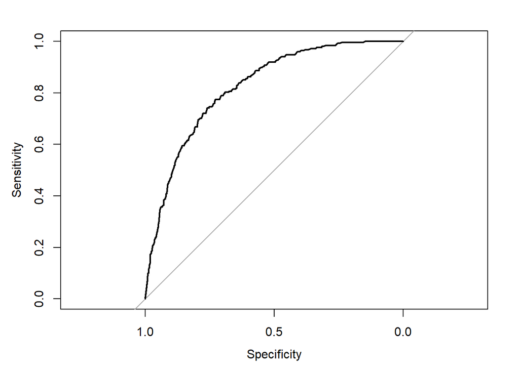

```
##
## Call:
## roc.default(response = model6$y, predictor = fitted(model6),     auc = TRUE, plot = TRUE)
##
## Data: fitted(model6) in 3837 controls (model6$y 0) < 247 cases (model6$y 1).
## Area under the curve: 0.823
```

```r
library(pROC)

roc(model6$y, fitted(model6), plot = TRUE, auc = TRUE)
```

The higher area under curve (AUC) value the better. The best (and theoretical in the same time) value is 1, meaning that model is perfectly able to distinguish between positive and negative stroke cases. The worst scenario is AUC equal to 0,5, meaning that the model has no predictive power. In case of my model the result 0,823 is good enough.

## Conclusions

Building such a model is a good example how modern statistic tools such as R package and advanced econometrics can support deep research on various health topics, which especially in the age of COVID pandemic (and possible forthcoming its mutations and new viruses) is gaining on its importance. I strongly believe, that with development of IT tools, statistical/econometric models and rich choice of data to analyse, in the forthcoming years we can witness breakthrough discoveries in this field. This is undoubtedly positive aspect of big data and its impact on human lives.

## Bibliography

http://www.fum.info.pl/ https://www.ncbi.nlm.nih.gov/ https://diabetyk24.pl https://www.cdc.gov/ https://thestatsgeek.com/ https://www.statisticshowto.com/ https://www.rdocumentation.org/ https://towardsdatascience.com/ https://www.kaggle.com/datasets https://pl.wikipedia.org/ https://rviews.rstudio.com/